# RCS Temporal Context Parameter Recovery Exercise

Hayley Brooks

2/16/2022

```r
# config
library('config')
config = config::get()

# load packages
library('parallel');
library('tictoc');
library('rio');
library("ggplot2")

# load functions
source('./binaryChoices.R'); # generate binary choices
source('./temporalContextProbChoice.R'); # probability and choice function
source('./negLLtempContext.R'); # negative likelihood function
source("./rcsTempContextParamRecov.R"); # optimizing function

eps = .Machine$double.eps;
```

Get our choice set function:

```r
choiceSetPath = file.path(config$path$code_files$choiceSetFx); # choice set path
source(choiceSetPath); # load choice set
```

Specify some temporal context beta values we’d like to recover. These are the “ground truth” values. These are based on VNI fixed effects results from a glmer model

1. Identify group-level fixed effects and errors for all of the parameters (incl. gain, safe, mean EV, past outcome, etc). Using error terms, create ‘less than’ and ‘more than’ options as wanted for the parameter estimates of the main effects of interest (i.e. for now we are just doing context effects variables and now gain/safe/meanEV things

TRIAL-LEVEL MODEL FROM VNI: model1_trialLevel = glmer(choice~ 0 + gainSC + altSC + grndEVscaled + (0+ gainSC + altSC|subjectIndex), data = mriBehClean, family = “binomial”);

#gainSC = 16.118(1.922) #altSC = -41.078(3.823) #grndEVscaled = 6.990(5.438)

CONTEXT EFFECTS MODEL FROM VNI: modelRCS_potc_posshift_earn_trial_intxns = glmer(choice~0 + earningsSC*poc1scaled + trialSC*poc1scaled + shiftDiffscPOS + (1|subjectIndex), data=mriBehClean, family=“binomial”, offset=pred); #AIC = 7547.1 ^^ note that we are using earnings scaled –> sum(poc scaled by max(riskyGain) which is 61)) –> then to make this variable work better in the model, its scaled again by max(earningsSC) which is 66.75 –> so we need to remember to do this scaling in the probability/likelihood functions –> we’d prefer to use the vni model with relative earnings but we can’t compute that in the estimation because scaling by variables that are generated in the future is…not possible. These results are similar between both models.

#earnings scaled twice = 1.5493(1.1074) –> lower = 0.4419; upper = 2.6567 #poc1scaled = -0.7730(0.1685) –> lower = -0.9415; upper = -0.6045 #expSC = -1.4531 (0.9589) #shiftDiffscPOS = 2.3303(0.7474) –> lower 1.5829; upper= 3.0777 #earnings scaled twice:poc1scaled = 5.2010(3.1168) #poc1scaled:expSC = -2.8280(2.7232)

^^ the input we give to the function needs to match with how these are scaled

# So now, we can create our subjects (3 levels of POC, positive shift and earnings relative to expectations = 27 participants)

```r
pocVals = c(-0.9415, -0.7730, -0.6045); # past outcome estimates
shiftVals = c(1.5829, 2.3303, 3.0777); # positive shift value estimates
earnVals = c(0.4419,1.5493,2.6567); # earning estimates
allVals = expand.grid(pocVals, shiftVals,earnVals);

nSub = nrow(allVals);
```

Set up meta-parameters for parameter recovery exercise

```r
iter = 1; # iterations per person (started with 700, but will lower to speed up testing)
ncores = 4; # cores we will use for parallel processing
cIter = 10; #iterations per core --> this may not be necessary for glm...make this 100 and see what the output is. If GLM is returning slightly different values, then the fit quality is good but if its not, we may just want to make this 1 to save processing power.
```

Now we use these to simulate choices using one big regression (the two-stage regression is about the estimation of correlated variables; you can apply them in one big regression w/o issue).

First, check that our code works by plotting choices, probabilities, etc

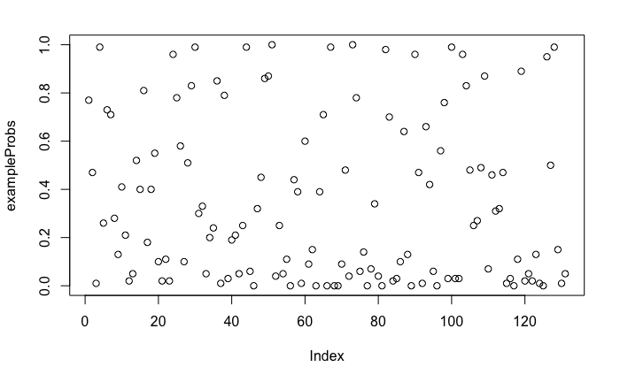

```r
exContextVals = c(-0.9415, 1.5829, 0.4419); # example poc, shift, and relative earning betas

cs = rcsChoiceSet(); # generate a choice set


newChoiceset = contextProbChoices(exContextVals, cs); # get probabilities and binary choices
exampleProbs = newChoiceset$prob;
exampleChoice = newChoiceset$choice;
# Scatter plots for probabilities, binary choices and both
plot(exampleProbs)
```

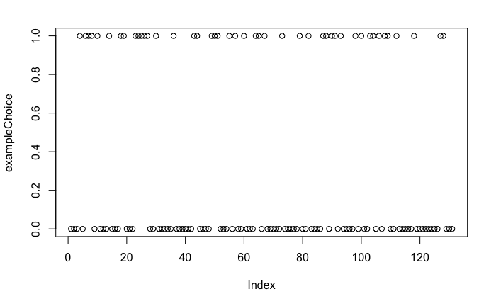

```r
plot(exampleChoice)
```

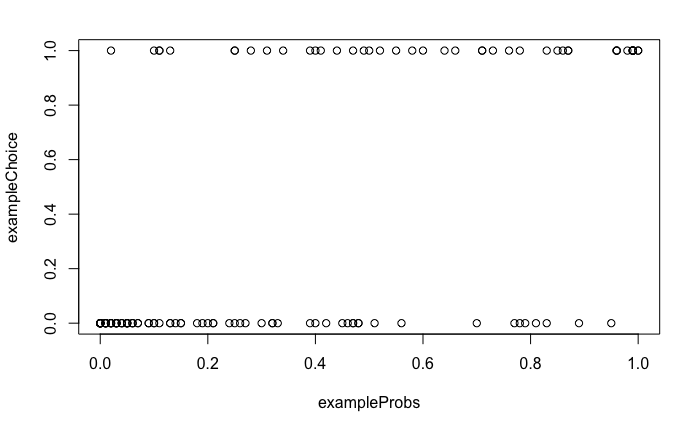

```r
plot(exampleProbs, exampleChoice);
```

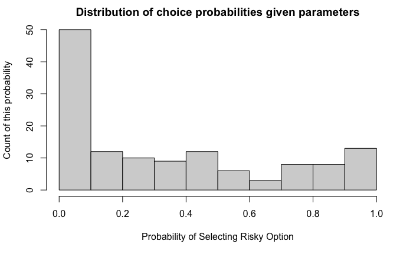

```r
# Plot histogram of choice probabilities to see how variable choices are predicted to be.
# code from PSH CLASE
hist(exampleProbs,xlab = 'Probability of Selecting Risky Option', ylab = 'Count of this probability', main = 'Distribution of choice probabilities given parameters');
```

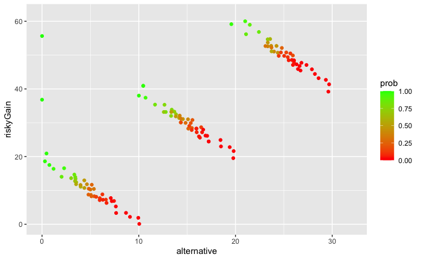

```r
exampleChoiceDF = data.frame(cs, exampleProbs, exampleChoice);


# Plot p(choose risky option) given parameters as a function of choice values (code based on PSH CLASE)
exampleProbabilisticPlot = ggplot(data = newChoiceset, aes(x = alternative, y = riskyGain)) +
  geom_point(aes(color = prob)) +
  xlim(c(0,32)) + ylim(c(0,62)) +
  scale_colour_gradient(low='red',high='green');
print(exampleProbabilisticPlot);
```

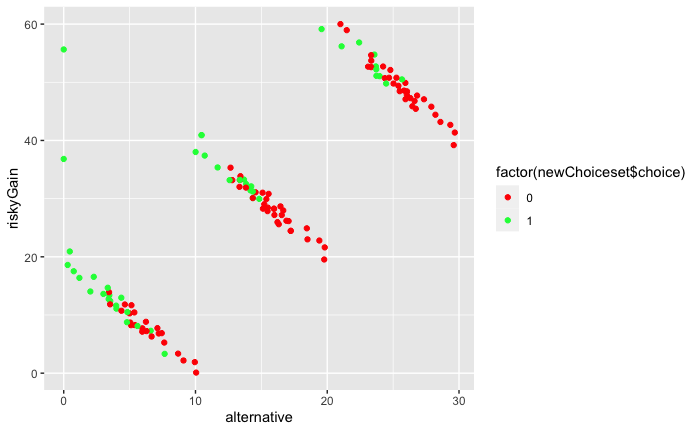

```r
# Plot simulated binary choices given parameters as a function of choice values (also based on PSH CLASE code)
exampleBinaryPlot = ggplot(data = newChoiceset, aes(x = alternative, y = riskyGain)) +
  geom_point(aes(color = factor(newChoiceset$choice))) + scale_color_manual(values = c('#ff0000','#00ff44'));
print(exampleBinaryPlot);
```

# Let’s do the parameter recovery!

```r
tempContextparRecResults = array(data = NA, dim = list(nSub,7,iter), dimnames = list(c(NULL), c("poc", "shift", "earn", "poc se", "shift se", "earn se", "aic"),c(NULL))); # stores for each person and iteration, the best optimization results

# Initialize the progress bar
progress_bar = txtProgressBar(min = 0, max = nSub, style = 3)
tic();
#for(n in 1:nSub){ # for each person
  #for(i in 1:iter){ # iteration per person

for (n in 1:3) {
  for (i in iter) {


    CS = rcsChoiceSet(); # generate a new choice set
    newCS = contextProbChoices(allVals[n,], CS); #new choiceset with the variables we need to run the rest (e.g. choice, past outcome)

    # now we use PT function to estimate parameter values based on generated choices
    indivEstimates = array(data=NA, dim = list(ncores,6,cIter)); # this will temporarily hold optimization results (pars and ll) from cores x cIter
    indivAIC = array(data=NA, dim = list(ncores,1,cIter));

    subjectn = newCS; # subject data is the new choiceset that includes choices, probabilities, past outcome, etc.

    outputlist = mclapply(1:ncores, mc.cores = ncores, function(i) rcsTempContextParRec(cIter,subjectn)); #do the work!



    for(c in 1:ncores){ #in each core
      for(r in 1:cIter){ # for each iteration
        if (typeof(outputlist[[c]][[r]]) == 'list'){ #if the output is a list -- this means optim worked
          indivEstimates[c,1:6,r] <- outputlist[[c]][[r]]$coefficients; # pull out the parameter values for each iteration in each core
          indivAIC[c,1,r] <- outputlist[[c]][[r]]$aic; # pull out aic

        } else { # put NA for iterations that didn't work
          indivEstimates[c,1:6,r] <- NA;
          indivAIC[c,1,r] <- NA;


        } # end if else statement
      } # end loop for r in 1:citer
    }; # end loop c in 1:ncore

      # PULL OUT MODEL WITH BEST AIC

      if (any(is.finite(indivEstimates))){ # if there was at least one iteration that worked then follow the next steps
        indBest <- which(min(indivAIC[,1,], na.rm = TRUE)==indivAIC,arr.ind = T); # get the index of the single best output across the cores & iterations
        bestoutput<- outputlist[[indBest[1,1]]][[indBest[1,3]]]; # use index to pull the best GLM results from the outputlist

        tempContextparRecResults[n,1:3,i]= bestoutput$coefficients[c(2,4,1)]; # store the parameter values for poc, shift, earnings

        tempContextparRecResults[n,7,i] = bestoutput$aic; # store the AIC value

        tmp = summary(bestoutput); # save summary so we can get the standard errors for this model
        tempContextparRecResults[n,4:6,i] =tmp$coefficients[c(8,10,7)]; # store the standard errors for outcome, shift and earnings

      } # end if any statement

    } # end the loop: for i in 1:iter
    setTxtProgressBar(progress_bar, n)

  }#end the loop: for n in 1:nSub
```

[output not shown]

[output not shown]

[output not shown]

```r
  close(progress_bar)
```

```r
  toc();
```

```
2.254 sec elapsed
```

```r
  #save(tempContextparRecResults, file = "parameterRecoveryOutputTempContext.Rdata");
```

```r
CIzscore = 1.96; # multiplier for calculating 95% confidence intervals (will be multiplied by standard errors)


  #past outcome
  # past outcome recovered estimates are in the 1st column and SEs are in the 4th column in each  matrix of tempContextparRecResults
  # in allVals, past outcome ground truth is 1st column
  goodcountPOC = 0
  badcountPOC =0
  nancountPOC=0
  estIndpoc = 1
  seIndpoc = 4

  for(s in 1:nSub){
    for(i in 1:iter){
      if(!is.nan(tempContextparRecResults[s,seIndpoc,i])){
        lowCI = tempContextparRecResults[s,estIndpoc,i] - (CIzscore*tempContextparRecResults[s,seIndpoc,i]); # low CI
        upCI = tempContextparRecResults[s,estIndpoc,i] + (CIzscore*tempContextparRecResults[s,seIndpoc,i]); # high CI
        if(allVals[s,estIndpoc] >= lowCI && allVals[s,estIndpoc] <= upCI){
          goodcountPOC = goodcountPOC + 1
        } else{
          #print(c(s,i)); # print the subs and the iteration that was not successful
          badcountPOC = badcountPOC+1
        }
      }else{
        #print(c(s,i,'nan'))
        nancountPOC = nancountPOC + 1
      }
    }
  }


  # positive shift
  # positive shift recovered estimates are in the 2nd column and SEs are in the 5th column in each  matrix of tempContextparRecResults
  # in allVals, positive shift ground truth is 2nd column
  goodcountShift = 0
  badcountShift =0
  nancountShift=0
  estIndshift =2
  seIndshift =5

  for(s in 1:nSub){
    for(i in 1:iter){
      if(!is.nan(tempContextparRecResults[s,seIndshift,i])){
        lowCI = tempContextparRecResults[s,estIndshift,i] - (CIzscore*tempContextparRecResults[s,seIndshift,i]); # low CI
        upCI = tempContextparRecResults[s,estIndshift,i] + (CIzscore*tempContextparRecResults[s,seIndshift,i]); # high CI
        if(allVals[s,estIndshift] >= lowCI && allVals[s,estIndshift] <= upCI){
          goodcountShift = goodcountShift + 1
        } else{
          #print(c(s,i)); # print the subs and the iteration that was not successful
          badcountShift = badcountShift+1
        }
      }else{
        #print(c(s,i,'nan'))
        nancountShift = nancountShift + 1
      }
    }
  }




  # earnings
  # earnings recovered estimates are in the 3rd column and SEs are in the 6th column in each  matrix of tempContextparRecResults
  # in allVals, earnings ground truth is 3rd column
  goodcountEarnings = 0
  badcountEarnings =0
  nancountEarnings=0
  estIndearnings =3
  seIndearnings =6

  for(s in 1:nSub){
    for(i in 1:iter){
      if(!is.nan(tempContextparRecResults[s,seIndearnings,i])){
        lowCI = tempContextparRecResults[s,estIndearnings,i] - (CIzscore*tempContextparRecResults[s,seIndearnings,i]); # low CI
        upCI = tempContextparRecResults[s,estIndearnings,i] + (CIzscore*tempContextparRecResults[s,seIndearnings,i]); # high CI
        if(allVals[s,estIndearnings] >= lowCI && allVals[s,estIndearnings] <= upCI){
          goodcountEarnings = goodcountEarnings + 1
        } else{
          #print(c(s,i)); # print the subs and the iteration that was not successful
          badcountEarnings = badcountEarnings+1
        }
      }else{
        #print(c(s,i,'nan'))
        nancountEarnings = nancountEarnings + 1
      }
    }
  }

  #2/28
  #roughly half (.4988) of iterations could not be computed because NaNs, half (.501) were not succesfully recovered, and .0002 (5 total) were recovered succesfully
  #roughly half (.4967) of positive shift ground truths could not be computed because NaNs, half (.503) were not successfully recovered, .0001 (2 total) were recovered successfully
  #roughly half of earning ground truths could not be computed because of NaNs (.4986), half were unsuccessful (.50), and 0 were successfully recovered

  # Overall, terrible recovery. The majority of recovered values are hitting the bounds (looking at histograms)
  # for past outcome, bounds are both at .2 and .5 (over 6000 at each bound)
  # for shift, ~8000 were at the lower bound .5, and ~5000 were at the upper bound of 4
  # for earnings, over 16000 at the .10 bound
```